# R Notebook

# 1. Data Exploration

Describe the size and the variables in the moneyball training data set. Consider that too much detail will cause a manager to lose interest while too little detail will make the manager consider that you aren’t doing your job. Some suggestions are given below. Please do NOT treat this as a check list of things to do to complete the assignment. You should have your own thoughts on what to tell the boss. These are just ideas.

## Summary Statistics

```
     INDEX         TARGET_WINS     TEAM_BATTING_H TEAM_BATTING_2B TEAM_BATTING_3B  TEAM_BATTING_HR  TEAM_BATTING_BB TEAM_BATTING_SO  TEAM_BASERUN_SB
 Min.   :   1.0   Min.   :  0.00   Min.   : 891   Min.   : 69.0   Min.   :  0.00   Min.   :  0.00   Min.   :  0.0   Min.   :   0.0   Min.   :  0.0
 1st Qu.: 630.8   1st Qu.: 71.00   1st Qu.:1383   1st Qu.:208.0   1st Qu.: 34.00   1st Qu.: 42.00   1st Qu.:451.0   1st Qu.: 548.0   1st Qu.: 66.0
 Median :1270.5   Median : 82.00   Median :1454   Median :238.0   Median : 47.00   Median :102.00   Median :512.0   Median : 750.0   Median :101.0
 Mean   :1268.5   Mean   : 80.79   Mean   :1469   Mean   :241.2   Mean   : 55.25   Mean   : 99.61   Mean   :501.6   Mean   : 735.6   Mean   :124.8
 3rd Qu.:1915.5   3rd Qu.: 92.00   3rd Qu.:1537   3rd Qu.:273.0   3rd Qu.: 72.00   3rd Qu.:147.00   3rd Qu.:580.0   3rd Qu.: 930.0   3rd Qu.:156.0
 Max.   :2535.0   Max.   :146.00   Max.   :2554   Max.   :458.0   Max.   :223.00   Max.   :264.00   Max.   :878.0   Max.   :1399.0   Max.   :697.0
                                                                                                                    NA's   :102      NA's   :131
 TEAM_BASERUN_CS TEAM_BATTING_HBP TEAM_PITCHING_H TEAM_PITCHING_HR TEAM_PITCHING_BB TEAM_PITCHING_SO  TEAM_FIELDING_E  TEAM_FIELDING_DP
 Min.   :  0.0   Min.   :29.00    Min.   : 1137   Min.   :  0.0    Min.   :   0.0   Min.   :    0.0   Min.   :  65.0   Min.   : 52.0
 1st Qu.: 38.0   1st Qu.:50.50    1st Qu.: 1419   1st Qu.: 50.0    1st Qu.: 476.0   1st Qu.:  615.0   1st Qu.: 127.0   1st Qu.:131.0
 Median : 49.0   Median :58.00    Median : 1518   Median :107.0    Median : 536.5   Median :  813.5   Median : 159.0   Median :149.0
 Mean   : 52.8   Mean   :59.36    Mean   : 1779   Mean   :105.7    Mean   : 553.0   Mean   :  817.7   Mean   : 246.5   Mean   :146.4
 3rd Qu.: 62.0   3rd Qu.:67.00    3rd Qu.: 1682   3rd Qu.:150.0    3rd Qu.: 611.0   3rd Qu.:  968.0   3rd Qu.: 249.2   3rd Qu.:164.0
 Max.   :201.0   Max.   :95.00    Max.   :30132   Max.   :343.0    Max.   :3645.0   Max.   :19278.0   Max.   :1898.0   Max.   :228.0
 NA's   :772     NA's   :2085                                                       NA's   :102                        NA's   :286
```

## Box Plot

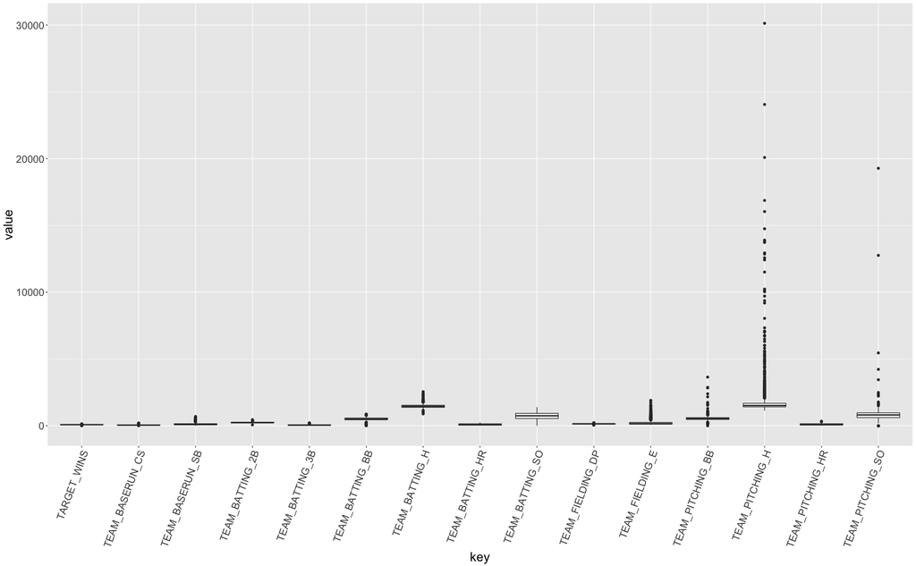

## Correlation Check

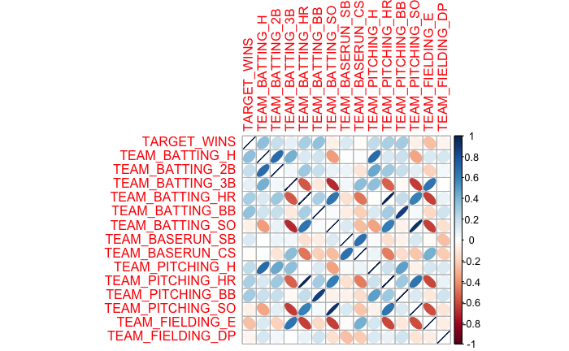

```
                 TARGET_WINS TEAM_BATTING_H TEAM_BATTING_2B TEAM_BATTING_3B TEAM_BATTING_HR TEAM_BATTING_BB TEAM_BATTING_SO TEAM_BASERUN_SB
TARGET_WINS       1.00000000    0.359102657      0.19377063      0.08273171     0.283464494      0.34829184     -0.06289963     0.120351295
TEAM_BATTING_H    0.35910266    1.000000000      0.67597673      0.42424339     0.121533598      0.16926595     -0.36556321     0.006327368
TEAM_BATTING_2B   0.19377063    0.675976730      1.00000000      0.04159537     0.313938180      0.19769347      0.07894699     0.065408077
TEAM_BATTING_3B   0.08273171    0.424243387      0.04159537      1.00000000    -0.554984363     -0.09728038     -0.69034724     0.045535545
TEAM_BATTING_HR   0.28346449    0.121533598      0.31393818     -0.55498436     1.000000000      0.28987751      0.64015910    -0.138348758
TEAM_BATTING_BB   0.34829184    0.169265952      0.19769347     -0.09728038     0.289877505      1.00000000      0.02384741    -0.078108165
TEAM_BATTING_SO  -0.06289963   -0.365563214      0.07894699     -0.69034724     0.640159102      0.02384741      1.00000000     0.126866866
TEAM_BASERUN_SB   0.12035129    0.006327368      0.06540808      0.04553554    -0.138348758     -0.07810816      0.12686687     1.000000000
TEAM_BASERUN_CS  -0.01119995    0.014056697     -0.11760390      0.36934182    -0.470715823     -0.20628472     -0.26423776     0.652338836
TEAM_PITCHING_H   0.21610375    0.687898063      0.45457406      0.35643177    -0.002382248      0.12825248     -0.34335935     0.021181111
TEAM_PITCHING_HR  0.27872264    0.136743031      0.31787719     -0.52736563     0.971652181      0.29599870      0.60500635    -0.130403756
TEAM_PITCHING_BB  0.29493756    0.188208391      0.19232998     -0.02376740     0.200030244      0.87467545     -0.05535063    -0.059437263
TEAM_PITCHING_SO -0.06673654   -0.330034165      0.09116245     -0.63929275     0.597391699      0.03414065      0.93221165     0.134325496
TEAM_FIELDING_E  -0.25450741    0.121279902     -0.19416232      0.64109245    -0.621227175     -0.16115860     -0.62668120    -0.011939775
TEAM_FIELDING_DP -0.04949709    0.148619532      0.04710052      0.00887003     0.070219016      0.16343997     -0.13647576    -0.255985407
                 TEAM_BASERUN_CS TEAM_PITCHING_H TEAM_PITCHING_HR TEAM_PITCHING_BB TEAM_PITCHING_SO TEAM_FIELDING_E TEAM_FIELDING_DP
TARGET_WINS          -0.01119995     0.216103749       0.27872264       0.29493756      -0.06673654     -0.25450741      -0.04949709
TEAM_BATTING_H        0.01405670     0.687898063       0.13674303       0.18820839      -0.33003416      0.12127990       0.14861953
TEAM_BATTING_2B      -0.11760390     0.454574060       0.31787719       0.19232998       0.09116245     -0.19416232       0.04710052
TEAM_BATTING_3B       0.36934182     0.356431774      -0.52736563      -0.02376740      -0.63929275      0.64109245       0.00887003
TEAM_BATTING_HR      -0.47071582    -0.002382248       0.97165218       0.20003024       0.59739170     -0.62122718       0.07021902
TEAM_BATTING_BB      -0.20628472     0.128252478       0.29599870       0.87467545       0.03414065     -0.16115860       0.16343997
TEAM_BATTING_SO      -0.26423776    -0.343359353       0.60500635      -0.05535063       0.93221165     -0.62668120      -0.13647576
TEAM_BASERUN_SB       0.65233884     0.021181111      -0.13040376      -0.05943726       0.13432550     -0.01193978      -0.25598541
TEAM_BASERUN_CS       1.00000000     0.069090246      -0.45085011      -0.14133608      -0.23168177      0.42695850      -0.21424801
TEAM_PITCHING_H       0.06909025     1.000000000       0.17271371       0.48745563      -0.05662127      0.14489262       0.12291613
TEAM_PITCHING_HR     -0.45085011     0.172713710       1.00000000       0.31601752       0.64681064     -0.60020742       0.07928388
TEAM_PITCHING_BB     -0.14133608     0.487455634       0.31601752       1.00000000       0.12892998     -0.09659142       0.16263604
TEAM_PITCHING_SO     -0.23168177    -0.056621268       0.64681064       0.12892998       1.00000000     -0.58691832      -0.11885440
TEAM_FIELDING_E       0.42695850     0.144892622      -0.60020742      -0.09659142      -0.58691832      1.00000000      -0.07870923
TEAM_FIELDING_DP     -0.21424801     0.122916134       0.07928388       0.16263604      -0.11885440     -0.07870923       1.00000000
```